# Travaux dirigés 4 - MAP201, thème équation différentielles

Le TP est à faire en python, où la réponse à chaque question est dans une cellule séparée. On veillera à écrire un code suffisamment clair pour être éventuellement réutilisé d'un exercice à l'autre.

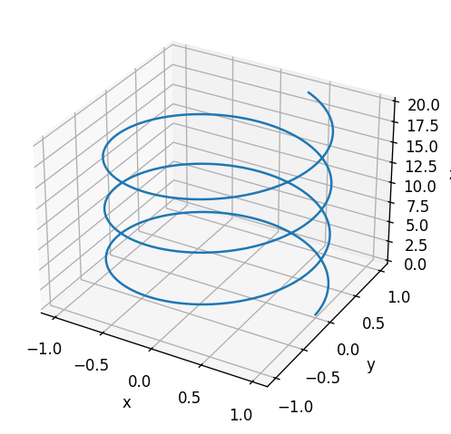

```python
import numpy as np #importe les outils de gestion des tableaux
import matplotlib.pyplot as plt #importe les outils d'affichages matplotlib
plt.rcParams['figure.dpi'] = 120 #reglage facultatif de résolution des figures
plt.rcParams['savefig.dpi'] = 240 #reglage facultatif de résolution des figures enregistrées


#On introduit une fonction qui affiche une courbe paramétrée en 3d.

def Affichage_Champs(f,g, xmin,xmax,ymin,ymax,N):
    #f,g: fonctions qui definissent le champs de vecteurs
    #xmin,xmax: intervalle d'abscisses affichees
    #ymin,ymax: intervalle d'ordonnees affichees
    #N: nombre de pas de discretisation
    x,y=np.meshgrid(np.linspace(xmin,xmax,N+1),np.linspace(ymin,ymax,N+1))
    u=f(x,y)
    v=g(x,y)
    u=u*(ymax-ymin)/(xmax-xmin)#Changement d'echelle.
    u,v=u/np.sqrt(0.01+u**2+v**2),v/np.sqrt(0.01+u**2+v**2)#Normalisation du champs de vecteur: cela permet de rendre plus visible la direction.
    plt.quiver(x,y,u,v)#affiche le champs de vecteur: cette fonction trace le vecteur (u[i,j],v[i,j]) base en (x[i,j],y[i,j]), pour i,j qui parcourent [0,N]x[0,N]


def f_exemple(x,y):
    return -np.sin(2*y+x)#expression de f(x,y)

def g_exemple(x,y):
    return np.sqrt(1+x**2+y**4)#expression de h(x,y)

#Affichage_Champs(f=f_exemple,g=g_exemple,xmin=-3,xmax=3,ymin=-2,ymax=2,N=15)


def affichage3d(X,Y,Z):
    ax = plt.axes(projection='3d')
    ax.plot3D (X,Y,Z)
    ax.set_xlabel('x')
    ax.set_ylabel('y')
    ax.set_zlabel('z')
    plt.show()

t=np.linspace(0,20,2000)
affichage3d(np.cos(t),np.sin(t),t)
```

```python
!jupyter nbconvert --to html TP_MAP201_2025_EDO_5.ipynb
```

# Exercice 1 - Modèle de Lotka-Volterra avec croissance limitée

On considère ici le modèle proie-prédateur de Lotka-Volterra, en ajoutant dans le modèle un terme supplémentaire qui limite la croissance de proies.

$$\begin{cases} \dot{x}(t)=x(t)(1- y(t)-\mu x(t))\\ \dot{y}(t)=y(t)(x(t)-1) \end{cases}$$

$\mu$ est un paramètre strictement positif.

## 1)

Quelle fonction représente le nombre de proies, et laquelle le nombre de prédateurs ? Pourquoi ?

Réponse:

# 2)

Donner une interprétation du terme $-\mu x(t)^2$.

Réponse:

## 3)

Calculer les points d'équilibres du système correspondant à des population positives (c'est-à-dire parmis les points $(x,y)\in \R^2$ tels que $x\geq 0$ et $y\geq 0$).

Réponse:

## 4)

En utilisant l'exercice précédent, afficher le champs de vecteur et plusieurs solutions (une dizaines) dans une fenêtre $[0,3]^2$. On fera cela pour plusieurs valeurs du paramètre $\mu\in [0.2,0.5,0.8,1,1.5,2,4]$, chacun dans une fenètre séparée. Quel changement observe-t-on sur le champs de vecteurs ?

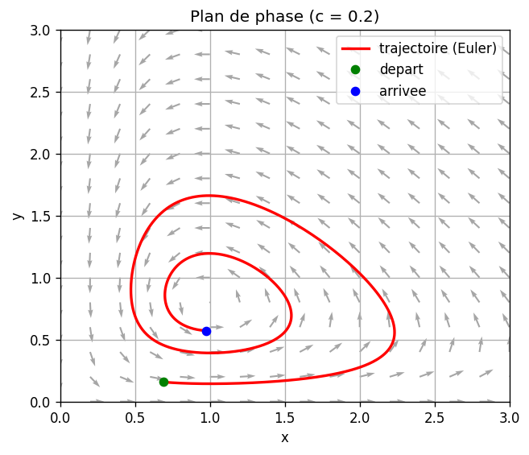

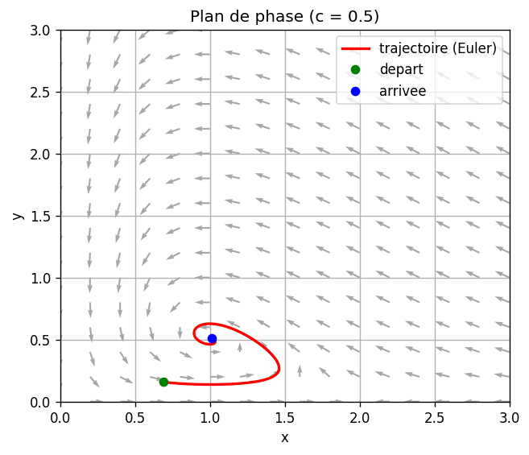

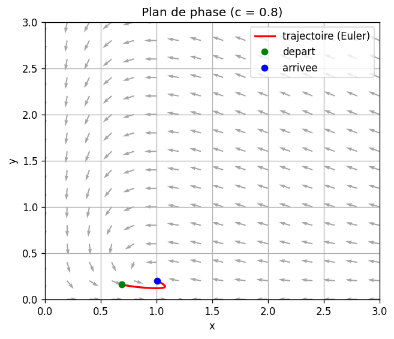

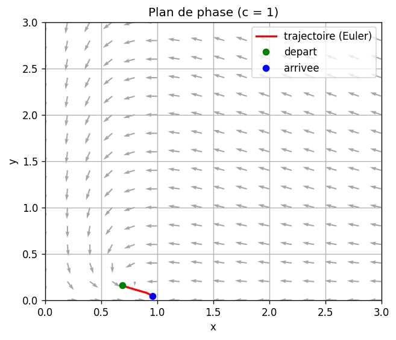

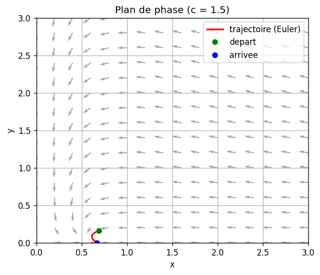

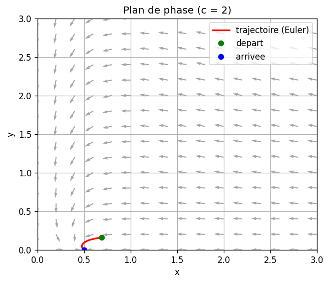

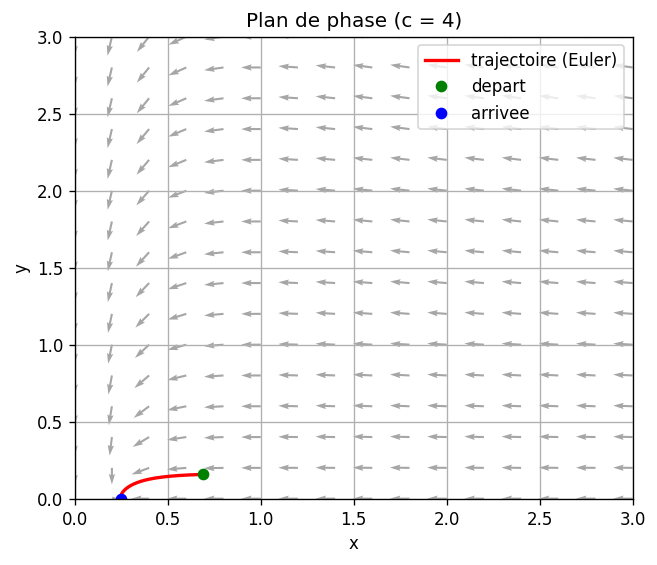

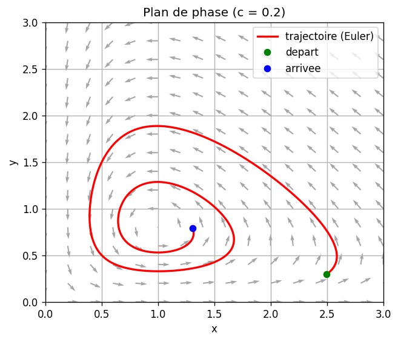

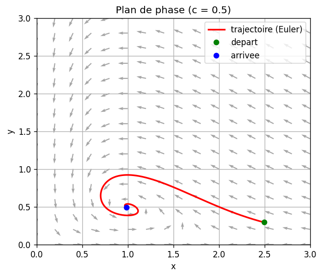

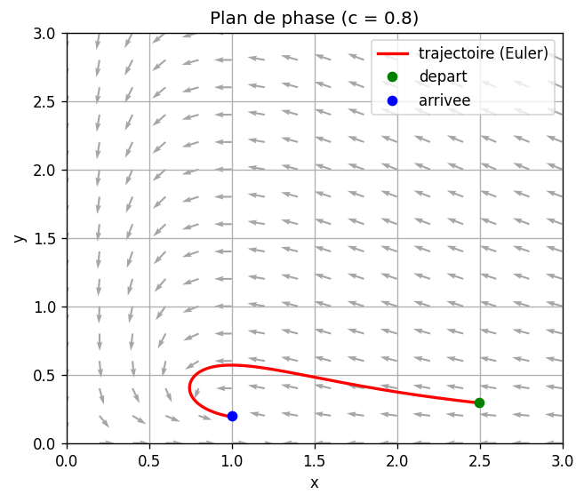

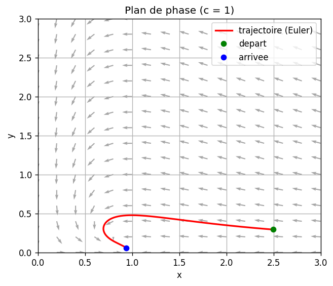

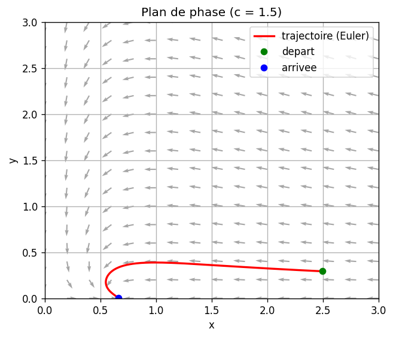

[23 more figures not shown]

```python
def plandephase(f, g, xmin, xmax, ymin, ymax, n, Tf, x0, y0, c):
    p = 15
    x_vals = np.linspace(xmin, xmax, p + 1)
    y_vals = np.linspace(ymin, ymax, p + 1)
    X, Y = np.meshgrid(x_vals, y_vals)

    U = f(X, Y, c)
    V = g(X, Y)

    # Changement d'échelle
    U = U * (ymax - ymin) / (xmax - xmin)
    U, V = U / np.sqrt(0.01 + U**2 + V**2), V / np.sqrt(0.01 + U**2 + V**2)

    dt = Tf / n
    X_e = np.zeros(n + 1)
    Y_e = np.zeros(n + 1)
    X_e[0] = x0
    Y_e[0] = y0

    for i in range(n):
        X_e[i + 1] = X_e[i] + dt * f(X_e[i], Y_e[i], c)
        Y_e[i + 1] = Y_e[i] + dt * g(X_e[i], Y_e[i])

    # Nouvelle figure pour chaque fenêtre
    fig, ax = plt.subplots(figsize=(6, 5))
    ax.quiver(X, Y, U, V, color='gray', alpha=0.7)
    ax.plot(X_e, Y_e, 'r-', label='trajectoire (Euler)', linewidth=2)
    ax.plot(X_e[0], Y_e[0], 'go', label='depart')
    ax.plot(X_e[-1], Y_e[-1], 'bo', label='arrivee')
    ax.set_xlim(xmin, xmax)
    ax.set_ylim(ymin, ymax)
    ax.set_xlabel("x")
    ax.set_ylabel("y")
    ax.set_title(f"Plan de phase (c = {c})")
    ax.legend()
    ax.grid(True)
    plt.show()

# Définition des fonctions f et g
def f(x, y, c):
    return x * (1 - y - c * x)

def g(x, y):
    return y * (x - 1)

# Paramètres
c_values = [0.2, 0.5, 0.8, 1, 1.5, 2, 4]
initial_conditions = [(np.random.uniform(0, 3), np.random.uniform(0, 3)) for _ in range(5)]
xmin, xmax = 0, 3
ymin, ymax = 0, 3
Tf = 15
n = 1000

# Générer les fenêtres
for x0, y0 in initial_conditions:
    for c in c_values:
        plandephase(f, g, xmin, xmax, ymin, ymax, n, Tf, x0, y0, c)
```

# Exercice 2 - Modèle de pèche

On considère une population de poissons $x(t)$ qui suit une équation logistique $\dot{x}(t)=x(t)(1-x(t))$ (toutes les constantes sont adimensionnées à $1$) en l'absence de pèche. On introduit un terme rendant compte de l'effet de la pèche: lorsque la population de poissons est petite, celui-ci est linéaire en la population, et lorsque la population est plus grande il atteint un seuil de prélèvement $h>0$. Cela donne l'équation différentielle

$$\dot{x}=x(1-x)-h\frac{x}{0.2+x}$$ ici $h>0$ est une constante positive.

## 1)

On fixe $h=0.15$. Afficher sur une même figure les courbes $\{(t,x_k(t))_{k=0,1,2,3,\dots,10},0\leq t\leq 20\}$ où $X_k(t)$ est la solution de l'équation ci-dessus avec la condition initiale $x_k(0)=\frac{k}{10}$. Puis donner une interprétation de l'effet de la pêche sur la population selon la population initiale $x^{init}$.

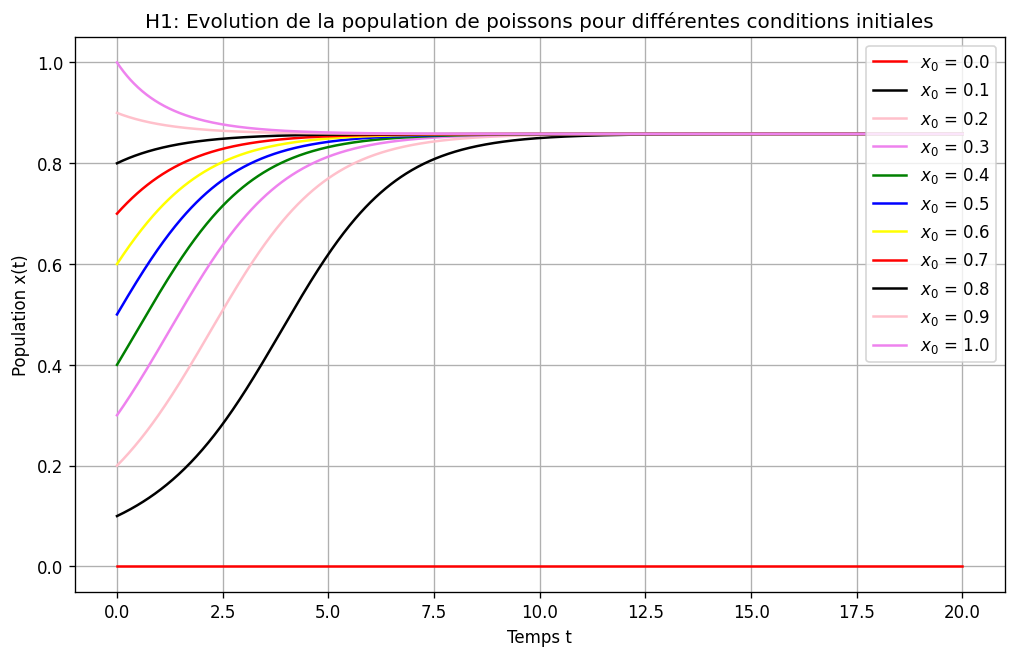

```python
#Réponse:
def d(x, h=0.15):
    return x*(1-x)-h*(x/(0.2+x))

def Euler(x0, Tfin, N, d):
    td = Tfin / N
    T=np.linspace(0,Tfin,N+1)
    X=np.zeros(N+1)
    X[0]=x0
    for i in range (N):
        X[i+1] = X[i] + td * d(X[i])
    return T, X


plt.figure(figsize=(10,6))
colors = ["red", "black", "pink", "violet", "green", "blue", "yellow"]


N = 1000
Tfin = 20
plt.figure(figsize=(10,6))
for k in range(11):
    x0 = k / 10
    T, X = Euler(x0, Tfin, N, d)
    plt.plot(T,X, label=f"$x_0$ = {x0:.1f}", color=colors[k%7])

plt.title("H1: Evolution de la population de poissons pour différentes conditions initiales")
plt.xlabel("Temps t")
plt.ylabel("Population x(t)")
plt.legend(loc="upper right")
plt.grid(True)
plt.show()
```

## 2)

Refaire la question avec $h=0.33$, puis $h=0.4$. Que remarque-t-on dans chaque cas ? Donner une interprétation en terme d'effet de la pêche sur l'extinction (ou non) de la population de poissons.

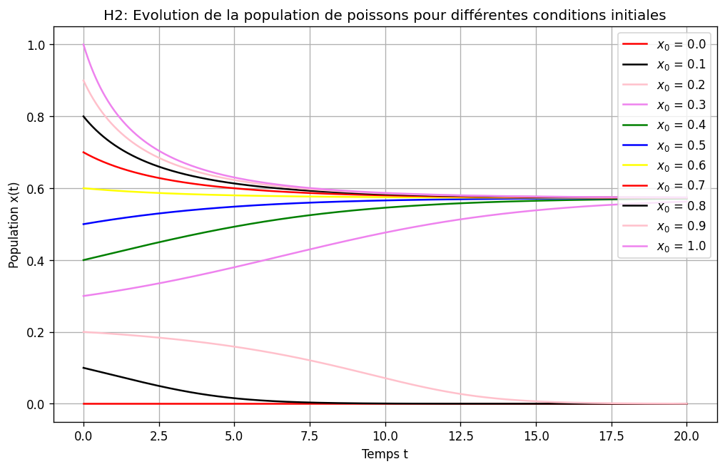

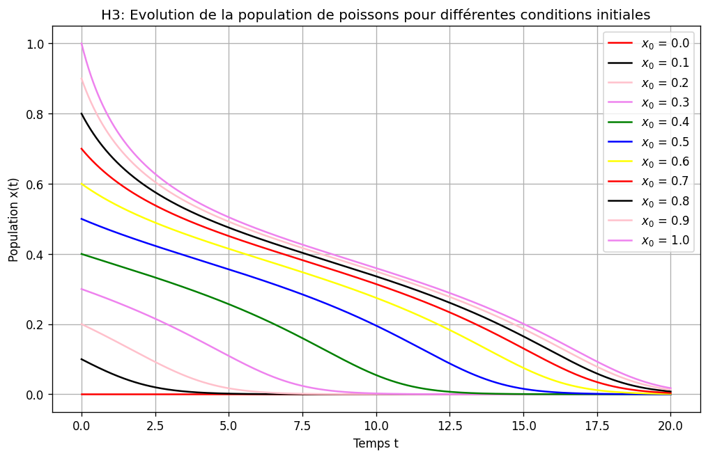

```python
#Réponse:
def h2(x, h=0.33):
    return x*(1-x)-h*(x/(0.2+x))
def h3(x, h=0.4):
    return x*(1-x)-h*(x/(0.2+x))

N = 1000
Tfin = 20
colors = ["red", "black", "pink", "violet", "green", "blue", "yellow"]

# 0.33
plt.figure(figsize=(10,6))
for k in range(11):
    x0 = k / 10
    T, X = Euler(x0, Tfin, N, h2)
    plt.plot(T,X, label=f"$x_0$ = {x0:.1f}", color=colors[k%7])

plt.title("H2: Evolution de la population de poissons pour différentes conditions initiales")
plt.xlabel("Temps t")
plt.ylabel("Population x(t)")
plt.legend(loc="upper right")
plt.grid(True)
plt.show()

# 0.4
plt.figure(figsize=(10,6))
for k in range(11):
    x0 = k / 10
    T, X = Euler(x0, Tfin, N, h3)
    plt.plot(T,X, label=f"$x_0$ = {x0:.1f}", color=colors[k%7])

plt.title("H3: Evolution de la population de poissons pour différentes conditions initiales")
plt.xlabel("Temps t")
plt.ylabel("Population x(t)")
plt.legend(loc="upper right")
plt.grid(True)
plt.show()
```

## 3)

Expliquer ce comportement par une analyse des points d'équilibre. On cherchera les valeurs de $h$ pour lesquelles le comportement change.

Réponse:

Pour h = 0.36 -> 2 points d'équilibre : bifurcation

Pour h > 0.36 -> 1 seul point d'équilibre :

- x = 0 (stable)
- extinction inévitable pour toute condition initiale

# Exercice 3

Tous les systèmes que l'on a vu précédemment adoptent un des comportement asymptotique (comportement en $t\to +\infty$) suivants: soit ils tendent vers un point d'équilibre, soit vers l'infini, soit vers une solution périodique. Il est possible de montrer que pour la plupart des équations différentielles à deux inconnues, ce sont les seuls comportements possibles: on va voir ici que ce n'est pas le cas pour les équations à trois inconnues. On s'intéresse à l'équation différentielle suivante:

$$ \begin{cases} \dot{x}(t)&=\sigma(y(t)-x(t))\\ \dot{y}(t)&=\rho x(t)-y(t)-x(t)z(t)\\ \dot{z}(t)&=x(t)y(t)-\beta z(t) \end{cases} $$ où $\sigma,\beta,\rho$ sont des constantes strictement positives: on fixera $$\sigma=10,\ \beta=8/3,\ \rho=28$$

Ce modèle à été proposé par Lorenz en 1963 comme modèle simplifié de convection de fluide en météorologie où $x,y,z$ décrivent certaines quantités physiques (quantité de mouvement, variation de température...) du fluide à un instant $t$.

## 1)

Quels sont les points d'équilibre du système ?

Réponse:

## 2)

Écrire une fonction qui prend en entrée une condition initiale $(x_0,y_0,z_0)$, un temps final $T^{fin}$, et un nombre de pas $N\in\N^*$, et calcule la solution approchée associée avec $N$ pas de temps (on pourra utiliser la méthode d'Euler, ou alors une des autres méthodes introduites dans les TP précédents).

```python
#Réponse:
```

## 3)

Afficher le résultat obtenu: on pourra afficher la courbe $(x(t),y(t),z(t))$ sur une première figure, et les graphes $(t,x(t))$, $(t,y(t))$, $(t,z(t))$ sur une seconde. On prendra $Tfin=40$, $N\geq 10 000$. On pourra prendre $(x0,y0,z0)$ un point aléatoire de $[-10,10]^3$.

Qu'observe-t-on ? Les solutions semblent-elles périodiques ?

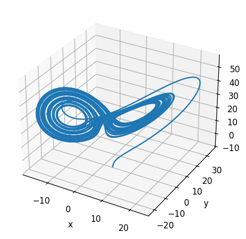

```python
#Réponse:
def d1(x,y, a=10):
    return a * ( y - x )
def d2(x,y,z, b=28):
    return b * x - y - x * z
def d3(x,y,z,c=8/3):
    return x * y - c * z

def Euler(x0, y0, z0, Tfin, N):
    td = Tfin/N
    T=np.linspace(0,Tf,N+1)
    X,Y, Z =np.zeros(N+1),np.zeros(N+1), np.zeros(N+1)
    X[0],Y[0], Z[0] = x0,y0,z0
    for i in range(N):
        X[i+1]=X[i]+td*d1(X[i],Y[i])
        Y[i+1]=Y[i]+td*d2(X[i],Y[i],Z[i])
        Z[i+1]=Z[i]+td*d3(X[i],Y[i], Z[i])
    return X,Y,Z,T

N = 10000
Tfin = 40
xmin = -10
ymin = -10
zmin = -10
xmax = 10
ymax = 10
zmax = 10
x0 = np.random.uniform(xmin,xmax)
y0 = np.random.uniform(ymin,ymax)
z0 = np.random.uniform(zmin,zmax)

X,Y,Z,T = Euler(x0, y0, z0, Tfin, N)
affichage3d(X,Y,Z)
```

## 4)

On résout l'équation de Lorenz pour deux conditions initiales différentes: une condition initiale $(x_0,y_0,z_0)$ prise aléatoirement dans $[-10,10]^3$, et la condition $(x_0+\epsilon,y_0,z_0)$ pour un petit paramètre $\epsilon>0$. Cela donne deux solutions $(x(t),y(t),z(t))$ et $(x_\epsilon(t),y_\epsilon(t),z_\epsilon(t))$. Afficher sur une même figure les graphes $(t,x(t))$ et $(t,x_{\epsilon}(t))$, pour les paramètres $\epsilon\in [0.01,0.001,0.0001]$. Que constate-t-on sur l'écart entre les deux solutions ?

Paramètres suggérés: $T^{fin}=30$, $N=100 000$. Il peut être nécéssaire de faire plusieurs tests pour voir ce qui se passe..

```python
#Réponse:
```

## 5)

Tracer l'évolution de l'écart $$t\mapsto \log_{10}( |x(t)-x_\epsilon(t)|+|y(t)-y_\epsilon(t)|+|z(t)-z_\epsilon(t)|)$$

en fonction de $t$, pour $t\in [0,Tfin]$. Comment évolue l'écart entre les deux solutions ?

## 6)

Que se passe-t-il Si on pose $\rho=20$ (au lieu de $28$)

```python
#Réponse:
```